# パート B

航空宇宙機の材料とその特性

# B1章

基本原理と定義

## B1.1 はじめに

航空宇宙構造エンジニアは、破壊に対する高い構造的完全性を維持しつつ、可能な限り構造重量を軽量化するという大きな設計要求に直面している。航空宇宙機における構造破壊は、人命の損失や機体の喪失につながる深刻な問題となることが多い。しかし、軍用機であるか民間機であるかを問わず、積載量や性能の観点から満足のいく航空宇宙機を実現するためには、構造重量の削減、すなわち破壊を防ぐために必要のないすべての構造重量を排除することに多大な努力を払わなければならないことが経験的に示されている。

航空宇宙機は、静的、動的、および繰り返し荷重など、広範な温度条件下で作用するさまざまな種類の荷重にさらされるため、安全で効率的な構造を得るためには、構造エンジニアが荷重下における材料の挙動について幅広い知識を持っている必要がある。このパート B では、荷重下における代表的な航空宇宙機用材料の挙動や、高温などの飛行環境で遭遇する様々な諸条件に関して、構造設計エンジニア向けの情報を提示する。

構造物の構成要素が柔軟すぎることによって、異なる形態の破壊が生じることもある。この柔軟性が空気力学的な力に影響を与え、機体の飛行特性を不満足なものにする可能性がある。場合によっては、この柔軟性が機体の喪失に直面するほど深刻ではないこともあるが、満足に動作する機体を提供するために構造を変更する必要があるため、これも一種の破壊（機能喪失）である。翼のねじり剛性不足のような過度の歪みは極めて深刻になることがあり、この過剰な変形が空気力学的・動的な力の蓄積を招き、フラッターや激しい振動を引き起こし、最終的には航空機の喪失を伴う破壊に至ることがある。

構造部材のもう一つの破壊の度合いを説明するために、インテグラル燃料タンクを備えた翼を考えてみよう。タンクを構成する補強された板材は、翼構造の一部でもある。一般に、これらの板材は、リベット接合部からの燃料漏れを防ぐために、航空機の運用条件下で座屈やしわが発生しないように設計されている。したがって、もし運用中にタンク壁の一部にしわが生じて燃料漏れが発生し、その結果、構造の修理や改修が必要になった場合、タンクはその機能を十分に果たせなかったため、破壊が発生したと言うことができ、これを修復するためには追加の費用が発生する。さらに例を挙げると、航空宇宙機には操縦翼面用の制御システムや推進装置の制御システムなど、多くの構造部材を含む多数のシステムが搭載されている。多くの場合、部材の過度な弾性的または非弾性的な変形がシステムの動作不良を引き起こす可能性があり、機体の喪失を伴うような深刻な破壊でなくても、その部材は機能を果たせなかったと見なされる。したがって、航空宇宙構造エンジニアは、航空宇宙機とそのシステムを構成する構造部材の様々なレベルの破壊を防止することに関与し、その責任を負っている。当然ながら、材料の挙動に関する知識が豊富であるほど、多種多様な構造破壊によるトラブルを回避できる可能性が高くなる。

## B1.2 構造物の破壊

航空宇宙機は、他のあらゆる機械と同様に、特定の任務を満足に遂行するように設計されている。機体のいずれかの構造部材が何らかの影響を受け、それが結果として機体の満足な性能に影響を与える場合、その部材は機能喪失（破壊）したとみなすことができる。したがって、「構造部材の破壊」という言葉はかなり広い意味を持つ。例えば、構造部材の破壊は、飛行中に過大な応力や荷重が発生し、部材が完全に破断することに起因する場合がある。この部材が主翼の桁（スパ）や主要な翼継手などである場合、通常は航空機の墜落や人命の損失につながるため、非常に深刻な破壊となる。同様に、着陸動作中に着陸装置の支柱（ストラット）が崩壊することも非常に深刻な破壊となり得る。構造部材の破壊は疲労によっても発生する可能性があり、疲労破壊は前兆なしに突発的に破断に至るため、これも極めて深刻な破壊の形態となり得る。

## B1.3 一般的な荷重の種類

構造部材の破壊は、荷重が加えられる方法に影響される。部材に荷重を加える時間に基づくと、2つの大きな分類を行うのが合理的である。すなわち、(1) 静的荷重 および (2) 動的荷重 である。説明および一般的な議論のために、これら2つの分類は以下のようにさらに細分化される。

- **静的荷重**
  - 持続荷重 (Continuous Loading)
  - 漸増または緩速荷重 (Gradually or slowly applied loading)
  - 繰り返し漸増荷重 (Repeated gradually applied loading)
- **動的荷重**
  - 衝撃または急速荷重 (Impact or rapidly applied loading)
  - 繰り返し衝撃荷重 (Repeated impact loading)

### 静的持続荷重

持続荷重とは、部材に長期間にわたって作用し続ける荷重のことである。最も一般的な例は、部材自体の自重や構造の自重（死荷重）である。航空機が飛行状態に入ると、主翼とその内部の重量は主翼に対する持続荷重となる。長期間にわたって内圧を受けるタンクも持続荷重の例である。持続荷重は長時間にわたって加えられるため、後に説明するクリープが発生しやすい環境を作り出す。航空機の場合、持続荷重は通常、同時に作用する他の荷重と組み合わされる。

### 静的漸増（緩速）荷重

静的漸増荷重とは、大きな衝撃や振動を伴わずに、最大値までゆっくりと増加する荷重である。荷重が加わる時間は、数秒から数時間に及ぶ場合がある。部材内の応力は荷重の増加に伴って増大し、荷重が一定になると応力も一定に保たれる。例えば、客室を与圧しながら上昇する航空機では、上昇に伴って機体外部と内部の気圧差が徐々に広がるため、胴体構造に加わる内圧荷重は緩やかに増加する。

### 静的繰り返し漸増荷重

漸増荷重が部材に対して多数回にわたって繰り返し加えられる場合、これを繰り返し荷重と呼ぶ。この荷重は、部材内の応力を最大値からゼロへ、あるいは最大引張応力から最大圧縮応力へといったサイクルを繰り返すような性質を持つことがある。繰り返し荷重を伴う状況は、1回あるいは数回の荷重適用であれば完全に安全であるような応力レベルであっても、繰り返されることで部材の破壊を引き起こす可能性があるため極めて重要である。繰り返し荷重は通常、前兆なしに脆性的な破断による破壊を引き起こすため、構造設計において重要視される。

### 動的（衝撃）荷重

動的荷重または衝撃荷重が部材に加えられると、顕著な衝撃や振動が発生する。このような挙動を引き起こすためには、荷重は静的荷重よりもはるかに迅速に加えられなければならない。この迅速な荷重付加により、部材内の応力は、同じ大きさの荷重が静的（すなわち、ゆっくりと）に加えられた場合よりも一時的に大きくなる。例えば、大きさ $W$ の重りを片持ち梁の自由端に静かに置くと、梁はたわみ、最終的に静的な最大たわみに達する。しかし、この同じ重り $W$ をわずか1フィートの高さから梁の端に落下させた場合、最大たわみは同じ静的荷重 $W$ によるものの数倍に達する。梁は振動し、最終的には静的荷重 $W$ の下と同じたわみで静止する。動的荷重を静止させる際、梁は落下する重り $W$ の位置エネルギーの変化に等しいエネルギーを吸収しなければならない。そのため、動的荷重は「エネルギー荷重」とも呼ばれる。

物理学の基本法則から、力は質量と加速度の積（ $F = Ma$ ）であり、加速度は速度の時間変化率に等しい。したがって、航空機やミサイルなどの物体の速度の大きさが変化するか、あるいは進む方向が変化すると、機体は加速され、これは機体に力が加わることを意味する。高速からの急引き起こしなどの過酷な飛行マニューバ時、高速飛行中に強い突風（ガスト）に遭遇した時、あるいは地上や水面への着陸時において、航空機に作用する外力は極めて急速に加えられ、これらは動的荷重に分類される。A4章では、航空機荷重が静的あるいは動的に分類されるかどうか、また航空機構造の設計においてそれらがどのように扱われるかについて議論している。

## B1.4 静的引張応力-ひずみ線図

材料の引張応力-ひずみ線図を描くための情報は、試験片に軸方向の引張荷重を加え、試験片がゼロから破断荷重まで静的（漸増的）に荷重を受ける間の、規定の標点距離における荷重とそれに対応する伸びを測定することによって得られる。結果を標準化するために、標準サイズの試験片が（ASTM）アメリカ材料試験協会によって規定されている。試験機のクロスヘッドの速度は、材料の降伏点に達するまでは、標点距離1インチあたり毎分1/16インチを超えてはならない。また、降伏点から材料の破断点までは、標点距離1インチあたり毎分1/2インチを超えてはならない。伸びを測定するための計器は、0.0002インチ以下の値を読み取れるように較正されていなければならない。引張応力-ひずみ線図から得られる情報は、強度設計、剛性設計、エネルギー吸収、品質管理、その他多くの用途において、エンジニアにとって不可欠なものである。

図 B1.1 は、3つの主要な分類に属する材料の代表的な引張応力-ひずみ線図を示している。このような線図の研究において、材料の挙動に関する様々な事実や関係が注目されており、この基本的な重要情報に対して標準的な用語と記号が用意されている。これらの用語について簡単に説明する。

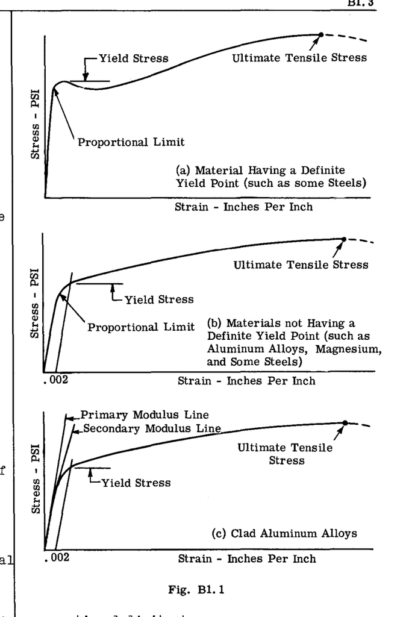

図 B1.1

### 縦弾性係数 (E)

弾性範囲における材料の変形に対する抵抗を定義する機械的特性は「剛性（stiffness）」と呼ばれ、延性材料では「縦弾性係数（Modulus of Elasticity）」と呼ばれる値で測定され、大文字の $E$ で表される。図 B1.1 を参照すると、3つのグラフすべての最初の部分は直線であり、これはこの範囲において応力とひずみの比が一定であることを示している。この比の数値を縦弾性係数（ $E$ ）と呼ぶ。したがって、 $E$ は応力-ひずみ線図の最初の直線部分の傾きであり、その数値は、平方インチあたりのポンド（psi）で表される応力を無次元のひずみで割ることによって得られる。すなわち、

$$E = \frac{f}{\epsilon}$$

であり、したがって $E$ は応力と同じ単位、すなわち平方インチあたりのポンド（psi）を持つ。

クラッド処理されたアルミ合金は、図 B1.1 の下の図に示すように、2つの $E$ の値を持つ。初期の弾性係数は他のアルミ合金と同じであるが、これは軟らかい純アルミ被覆材の比例限度応力までしか維持されない。このポイントの直上には短い遷移段階があり、その後、材料はより強度の高い芯材の比例限度応力に達するまで、二次的な弾性係数を示す。この二次の弾性係数は、図中の2番目の直線の傾きに相当する。どちらの弾性係数の値も、芯材と被覆材の両方を含む総断面積（グロスエリア）を用いた応力に基づいている。

### 引張比例限度応力 ( $F_{tb}$ )

比例限度応力とは、応力-ひずみ曲線が、単位ひずみ $0.0001$ だけ最初の直線部分から外れるときの応力である。一般に、比例限度応力は材料の弾性領域と非弾性領域の間の実用的な境界線を与える。弾性係数は、比例限度応力までは一定であるとみなされる。

### 引張降伏応力 ( $F_{ty}$ )

図 B1.1 の一番上の図を参照すると、一部の材料は、極限引張強さ（最大強さ）よりかなり低い応力において、荷重がほとんど、あるいはまったく増加しないにもかかわらず、材料が大きく伸びる明確な折れ曲がりを示す。これが起こる応力は「降伏点」または「降伏応力」と呼ばれる。しかし、多くの材料、およびほとんどの航空宇宙機用材料は、このような明確な折れ曲がりを示さず、図 B1.1 の中央の図に示すように、より緩やかに降伏する。したがって、上述のような明確な降伏点は存在しない。ほとんどの構造物や機械において、著しい永久変形が生じることは好ましくないため、設計目的で許容される永久ひずみの量を任意に設定するのが一般的な実務である。試験機関は、この永久ひずみ（オフセット）の値を $0.002$ （ $0.2\%$ ）と定めており、材料から荷重を取り除いたときにこの永久ひずみを生じさせる原因となった応力を「降伏応力」と呼ぶ。図 B1.1 は、これがどのように決定されるかを示している。図 B1.1 は、ひずみ軸上の $0.002$ の点から応力-ひずみ曲線の直線部分に平行な線を引き、この平行線が応力-ひずみ曲線と交わる点をグラフィカルに求める方法を示しており、この交点が降伏強度または降伏応力を表す。

### 極限引張応力 ( $F_{tu}$ )

極限引張応力は、試験片が持ちこたえた最大荷重における応力である。この応力は、試験中の試験片の横収縮（ネックイン）を考慮せず、試験前の元の断面積に基づいていることを認識しておく必要がある。したがって、実際の、あるいは真の応力は、従来の応力-ひずみ線図にプロットされた値よりも大きくなる。図 B1.2 は、応力-ひずみ線図にプロットされる実際の応力と見かけの応力との一般的な関係を示している。この差は、塑性領域のより高い部分に達するまではそれほど顕著ではない。

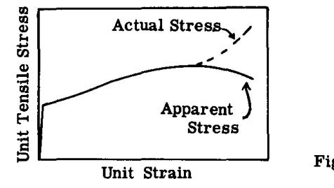

図 B1.2

図 B1.3 および 図 B1.4 は、いくつかの代表的な航空機材料の引張応力-ひずみ曲線の形状を比較したものである。

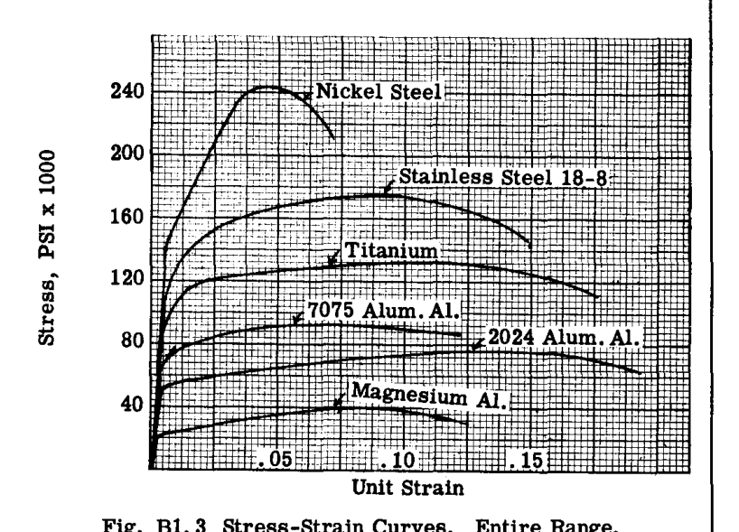

図 B1.3

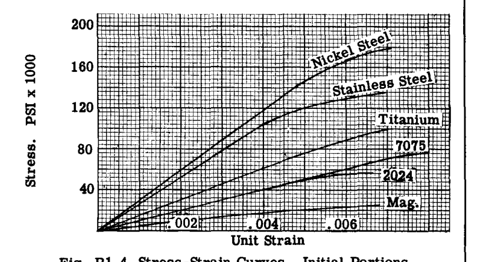

図 B1.4

## B1.5 静的圧縮応力-ひずみ線図

航空宇宙機の構造設計においては、安全性を確保し、かつ構造重量を軽量化することが極めて重要であるため、エンジニアは引張および圧縮の全応力範囲にわたる全体的な応力-ひずみ挙動を考慮しなければならない。これは、航空宇宙機の構造において、一次座屈および局所座屈の両方が一般的な破壊形態であり、これらの破壊が弾性領域または塑性領域のいずれの応力下でも発生する可能性があるためである。一般に、応力-ひずみ曲線が最初の直線部分から外れていく際の形状は、引張応力下と圧縮応力下で異なっている。さらに、様々な航空宇宙機用材料は、直線部分に隣接する応力-ひずみ曲線の領域において、それぞれ異なる形状を有している。構造の軽量化は非常に重要であるため、設計において高い許容圧縮応力を発揮させるために多大な努力が払われており、多くの航空宇宙機構造部材において、これらの許容極限設計圧縮応力は非弾性または塑性領域に位置している。

図 B1.5 は、広く使用されている4つのアルミニウム合金について、引張と圧縮の応力-ひずみ曲線を比較したものである。比例限度応力を下回る領域では、縦弾性係数は引張応力下でも圧縮応力下でも同一である。圧縮における降伏応力は、引張について説明したのと同様の方法で決定される。

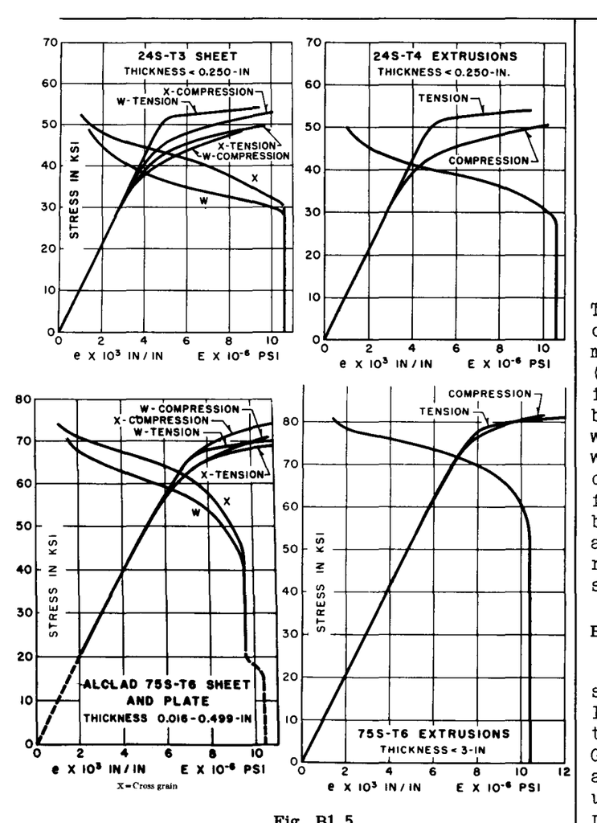

図 B1.5

### 極限圧縮応力 ( $F_{cu}$ )

静的引張応力下では、特定の材料からなる部材の極限引張応力は、部材の断面積の形状や長さによってほとんど影響を受けない。しかし、圧縮応力下では、部材の極限圧縮強さは、部材の断面積の形状と長さの両方に大きく影響される。いかなる部材も、極めて短く頑丈でない限り、圧縮応力を受けると、全体として横方向に座屈するか、あるいは局所的に横方向の座屈や圧壊（クリップリング）を起こす傾向がある。部材が十分に短いか、あるいは横方向の座屈に対して拘束されている場合、石、木材、および一部の金属などの材料の破壊は、明確な破断を伴うため、極限圧縮応力の明確な値が得られる。しかし、ほとんどの航空機用材料は非常に延性に富んでいるため、圧縮において破断は生じず、材料が降伏して膨張するため、増加した断面積がさらに大きな荷重を支える傾向がある。したがって、何らかの任意の測定基準や判定基準を設けなければ、延性材料の極限圧縮応力の値を選択することは実質的に不可能である。展伸材（Wrought materials）の場合、通常は $F_{cu}$ は $F_{tu}$ に等しいと仮定される。引張に比べて圧縮に比較的弱い脆性材料については、短いコンパクトな試験片の圧縮試験を行うことで、 $F_{tu}$ よりも高い $F_{cu}$ を得ることができ、この極限圧縮応力は一般に「ブロック圧縮応力」と呼ばれる。

## B1.6 接線係数・割線係数

他の章で詳細に説明されているように、部材の圧縮応力が非弾性領域にある場合の構造部材の圧縮強度を計算するための現代の構造理論では、部材の剛性を測定するために2つの追加の用語または値が使用される。これらの用語は、「接線割線弾性係数（tangent modulus of elasticity, $E_t$ ）」および「割線弾性係数（secant modulus of elasticity, $E_s$ ）」である。弾性係数（ $E$ ）のこれら2つの変形は、塑性領域において適用され、図 B1.6 に示されている。接線係数 $E_t$ は、検討対象の点における応力-ひずみ曲線の接線を描くことによって決定される。

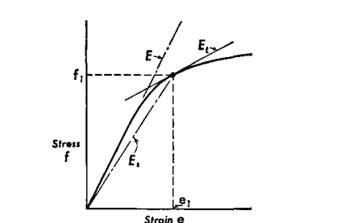

図 B1.6

この接線の傾きは、その点におけるひずみに対する応力の局所的な変化率を示す。割線係数 $E_s$ は、原点から検討対象の点へ割線（直線）を引くことによって決定される。この係数は、応力と実際のひずみの比を測定するものである。接線係数が応力によってどのように変化するかを示す曲線は、接線係数曲線と呼ばれる。図 B1.5 は、4つの異なるアルミニウム合金に関するこれらの曲線を示している。接線係数は、弾性範囲内では縦弾性係数と同一であり、応力が塑性範囲で高くなるにつれてその値が小さくなることに留意されたい。

## B1.7 弾性・非弾性挙動

部材が特定の応力を受けると、部材は特定のひずみを起こす。応力を取り除いたときにこのひずみが消失する場合、この挙動は「弾性（elastic）」と呼ばれる。一般的に、実用上の目的から、材料は前述のように定義された比例限度応力までの応力下では弾性挙動を示すとみなされる。図 B1.7 は弾性挙動を示している。しかし、応力を取り除いた後も残留ひずみが残る場合、この挙動は一般に「非弾性（inelastic）」または「塑性（plastic）」と呼ばれる。図 B1.8 は非弾性挙動を示している。

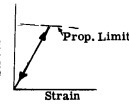

図 B1.7

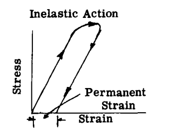

図 B1.8

## B1.8 延性

工学的な観点から「延性（ductility）」という用語は、破断することなく引張またはせん断において大きな非弾性的（塑性的）変形を起こす材料の大きな能力を示し、破壊に至るまでの塑性変形能力がほとんどないことを示す「脆性（brittleness）」という用語と対比される。物理的な観点からは、延性は材料がワイヤーや管に引き伸ばされたり、鍛造やダイカストされたりする能力を測定する用語である。延性は通常、破断後の引張試験片の特定の標点距離における「伸び率（パーセント伸び）」によって測定され、材料を比較するための十分に正確な値として一般に使用される。

$$\text{伸び率} = \left( \frac{L_a - L_o}{L_o} \right) 100 = \text{延性の尺度}$$

ここで、 $L_o$ は元の標点距離、 $L_a$ は破断後の標点距離である。伸び率によって延性を表す場合、総ひずみの大部分は破断直前の標点距離のネックダウン（くびれ）部分で発生するため、標点距離を明記することが重要である。標点距離が異なると、伸び率の値も変化するためである。

## B1.9 エネルギー吸収能・レジリエンス・靭性

### レジリエンス (弾性エネルギー吸収能)

材料が弾性範囲においてエネルギーを吸収する能力は「レジリエンス」と呼ばれる。レジリエンスの尺度として「レジリエンス係数（modulus of resilience）」という用語があり、これは材料に応力を加え、応力を取り除いたときに完全に回収される、単位体積あたりに蓄えられ得る最大エネルギー量として定義される。レジリエンス係数を計算するための弾性挙動の最大応力は、通常、比例限度応力とされる。したがって、単位体積（1立方インチ）の材料について、比例限度応力まで材料に応力を加える際に行われる仕事は、平均応力 $f_p/2$ に1インチあたりの伸び（ $\epsilon_p$ ）を掛けたものに等しくなる。 $U$ をレジリエンス係数とすると、次のように表される。

$$U = \left( \frac{f_p}{2} \right) \epsilon_p \quad \text{--- (1)}$$

しかし、 $\epsilon_p = f_p/E$ であるため、したがって、

$$U = \left( \frac{f_p}{2} \right) \left( \frac{f_p}{E} \right) = \frac{f_p^2}{2E} \quad \text{--- (2)}$$

軸方向荷重の条件下では、レジリエンス係数は、比例限度応力に達するまでの応力-ひずみ曲線の下側の面積として求めることができる。したがって、図 B1.9 において、面積 OAB は材料にゼロから比例限度応力まで応力を加える間に吸収されるエネルギーを表している。

スプリングのように衝撃を受ける部材には、高いレジリエンスが求められる。式 (1) から、比例限度応力が高く、この応力におけるひずみが大きい場合に、高いレジリエンスの値が得られる。また、式 (2) からは、比例限度応力が高く、縦弾性係数が低い場合に高いレジリエンスが得られる。

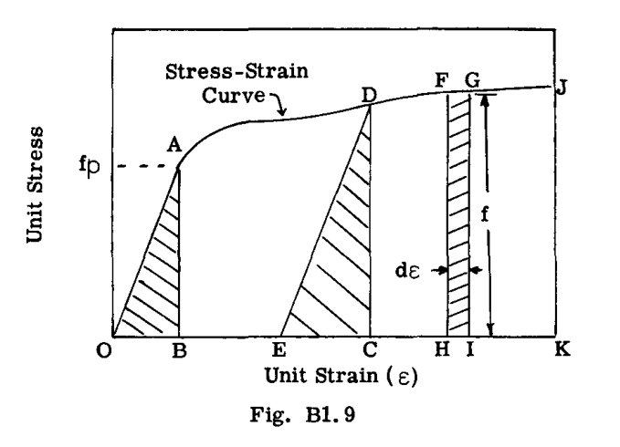

図 B1.9

図 B1.9 において、応力が塑性領域の点 D から除荷される場合、回復曲線は AO にほぼ平行な直線 DE となり、面積 CDE は放出されるエネルギーを表し、これはしばしば「超弾性レジリエンス（hyper-elastic resilience）」と呼ばれる。

### 靭性

材料の「靭性（toughness）」は、塑性領域において応力を受けたときにエネルギーを吸収する能力として定義される。「エネルギー」という言葉が含まれていることから、別の定義としては、動的荷重下において破断に抵抗する材料の能力とも言える。靭性は通常、「靭性係数（modulus of toughness）」という用語で測定され、これは極限強さの値まで応力を加えられたときに単位体積あたりに吸収されるひずみエネルギーの量である。

図 B1.9 において、 $f$ を $F$ から $G$ までの単位ひずみ距離 $d\epsilon$ における平均応力とする。このとき、 $F$ から $G$ まで応力を加える際に単位体積あたりに行われる仕事は $f d\epsilon$ であり、これは面積 FGHI で表される。極限応力 $f_u$ まで応力を加える際に行われる総仕事量は、次式に等しくなる。

$$\int_0^{\epsilon_k} f d\epsilon$$

これは、極限応力点までの応力-ひずみ曲線全体の下側の面積、すなわち図 B1.9 の面積 OAJ KO に相当し、単位は $\text{in.-lb./cu. in.}$ である。厳密に言えば、これには弾性レジリエンスや弾性範囲で吸収されるエネルギーを含めるべきではないが、塑性範囲の曲線の下側の面積に比べてこの面積は小さいため、通常は靭性の測定値に含まれる。

軸方向に加えられる動的荷重に抵抗する部材の能力は、部材の長さを長くすることによって向上することに留意されたい。これは、体積が長さに比例して直接増加するためである。しかし、極限強さは断面積の関数であり、材料の体積には依存しないため、同一のままである。

靭性は、衝撃や動的荷重に抵抗するように設計する際に望ましい特性である。なぜなら、実際の使用において過負荷が発生し、部材が塑性領域にかなり深く入るまで応力を受けた場合に、破断による破壊に対する予備強度や安全率を与えるからである。

延性の特性は靭性を生み出すのに役立つが、図 B1.10 に示されているように、延性のみが靭性を決定するわけではない。

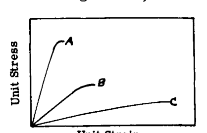

図 B1.10

図 B1.10 は、3つの異なる材料の応力-ひずみ曲線を示している。材料 (A) は強度が極めて高いが脆く、材料 (C) は強度は低いが延性に富み、材料 (B) は平均的な強度と延性を示している。しかし、3つの曲線の下側の面積はすべて同じであるため、これら3つの材料はすべて同じ靭性係数を持っている。

## B1.10 ポアソン比

材料に応力が加わると、応力の方向（軸方向）に変形すると同時に、それと直交する方向（横方向）にも変形する。軸方向の荷重において、比例限度応力を下回る応力に対して、応力方向と直交する方向の単位ひずみと、応力方向の単位ひずみとの比を「ポアソン比（Poisson’s ratio）」と呼ぶ。これは、試験片の引張または圧縮試験において直接測定することによって決定され、鋼では約 $0.3$ 、非鉄材料では約 $0.33$ に等しい。多くの構造物において、部材は複数の方向（例えば、3つの座標軸すべてに沿った方向）の応力を受ける。ポアソン比は、様々な方向における結果としての応力や変形を決定するために使用される。

### 塑性領域におけるポアソン比

塑性領域、特に弾性から塑性挙動への遷移領域におけるポアソン比に関する情報は、やや限られている。塑性的に非圧縮性である等方性固体を仮定すると、ポアソン比は $0.5$ の値をとる。Gerard と Wildhorn はその研究から、プラスチック領域におけるポアソン比の弾性値の約 $1/3$ から $1/2$ への移行は緩やかであり、応力-ひずみ曲線の降伏点領域において最も顕著であることを突き止めた。

## B1.11 既知の試験応力-ひずみ曲線を用いた、指定された降伏応力を通る応力-ひずみ曲線の作成

材料は一般に、降伏応力や極限引張応力などの特定の保証された最小強度特性を満たすように製造される。したがって、複合構造における重要な部材の設計においては、必要な安全度を確保するために、最小保証特性を使用しなければならない。一般に、ほとんどの材料は保証値をわずかに上回る特性を示すため、購入した材料の実測応力-ひずみ曲線をそのまま設計目的に使用することはできない。特定の降伏応力を通る応力-ひずみ曲線は、以下のようにして実測応力-ひずみ曲線から容易に得ることができる。

$$OD = \frac{OA}{OB} \times OC$$

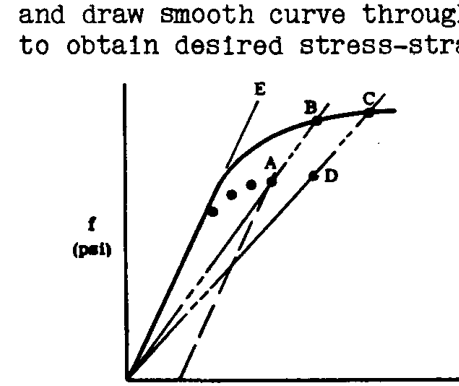

図 B1.11

## B1.12 無次元応力-ひずみ曲線

構造設計者は、非弾性不安定性によって破壊する構造部材の設計に常に直面している。このような問題の解決には、圧縮応力-ひずみ曲線によって提供される情報が必要である。航空宇宙機は多くの異なる材料を使用しており、各材料は通常、異なる機械的特性を与える多くの異なる製造状態を持っているため、応力-ひずみ曲線から特定の設計情報を得るために必要な時間の問題が重要になってくる。例えば、アルミニウム合金だけでも約100種類の異なる合金があり、様々な時間暴露における高温条件が加わると、必要とされる応力-ひずみ曲線の数はさらに大幅に増加する。

幸いなことに、Ramsberg と Osgood（文献1）が降伏領域における応力-ひずみ曲線を記述する式を提案したことで、この時間のかかる作業は大幅に削減された。彼らの提案した式は、3つのパラメータ、すなわち縦弾性係数 $E$ 、割線降伏応力 $F_{0.7}$ （これは原点から引いた傾き $0.7E$ の直線と曲線との交点、図 B1.12 参照）、および降伏領域における応力-ひずみ曲線の形状を記述するパラメータ $n$ を用いて応力-ひずみ曲線を規定する。パラメータ $n$ を評価するためには、もう一つの応力 $F_{0.85}$ が必要であり、これは原点を通る傾き $0.85E$ の直線と曲線との交点である（図 B1.12 参照）。

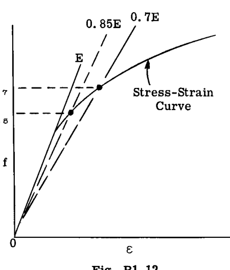

図 B1.12

Ramsberg と Osgood が提案した、非弾性領域における応力-ひずみ関係の3パラメータ表現は以下の通りである。

$$\frac{E\epsilon}{F_{0.7}} = \frac{f}{F_{0.7}} + \left( \frac{f}{F_{0.7}} \right)^n \quad \text{--- (3)}$$

$n$ を求める式は以下の通りである。

$$n = 1 + \frac{\log_e(17/7)}{\log_e(F_{0.7}/F_{0.85})} \quad \text{--- (4)}$$

図 B1.13 は式 (4) のプロットである。無次元量 $E\epsilon/F_{0.7}$ は、図 B1.14 の無次元曲線を決定する際に使用できる。これらの曲線を使用して値を得るためには、 $E$ 、 $n$ 、および $F_{0.7}$ が既知でなければならない。

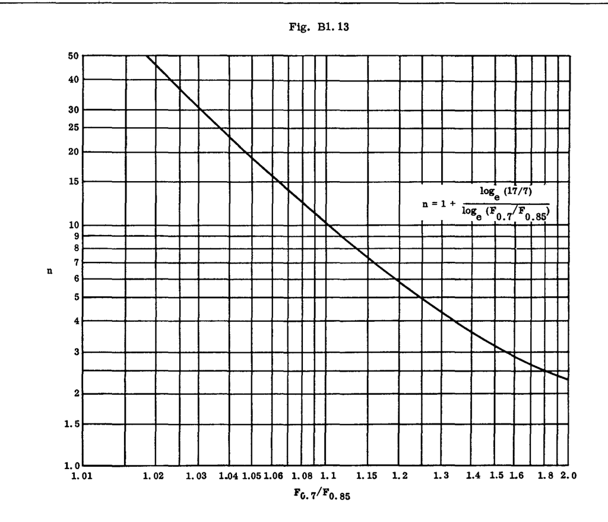

図 B1.13

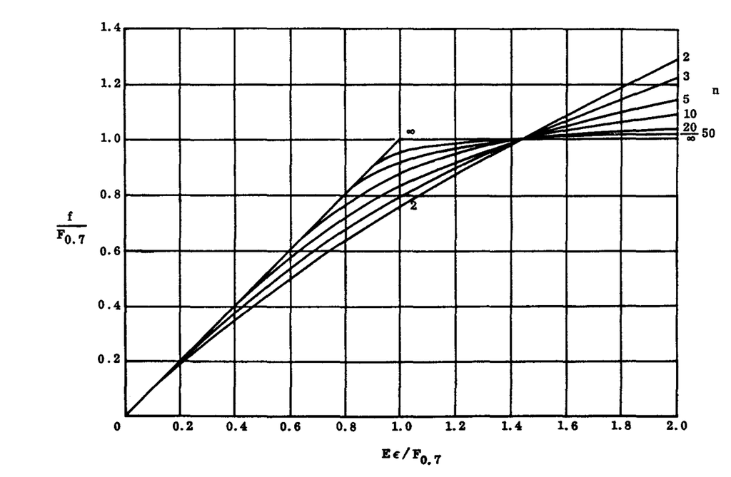

図 B1.14

## B1.13 材料特性に対する温度の影響

超音速飛行機や長距離ミサイルが登場する以前は、航空機の機体構造設計において材料の通常の静的機械的特性を使用することができた。これは、当時の航空機が遭遇する温度上昇が材料の強度特性にほとんど影響を及ぼさなかったためである。ジェットエンジンやロケットエンジンの開発により、超音速および宇宙飛行という全く新しい分野への道が開かれた。これにより、飛行環境条件は大幅に拡大し、主な変化として、大気中における高速飛行に起因する空力加熱が機体表面温度を上昇させ、これが通常の静的な材料強度特性に多大な影響を及ぼすようになった。したがって、特定の種類の航空宇宙機の構造設計において、温度と時間が重要な要素となった。

## B1.14 材料のクリープ

温度が非常に高くなると、材料が溶融または流動し、構造部材としての荷重支持能力を失うため、温度が材料を弱体化させることは明らかである。応力を受けている部材が温度にさらされると、よく知られている熱膨張に加えて、形状の変化が生じる。材料に対する温度と時間のこの全般的な影響を記述するために「クリープ（creep）」という用語が使用される。クリープは一般に、高温下において応力を受けた状態での、進行性で比較的緩やかな形状の変化と定義される。クリープの簡単な例として、非常に暑い夏の日にアスファルト道路の上に立っている人が挙げられる。その場所に長く立っているほど、靴底は道路の表面に深く沈み込むが、寒い冬の日であれば、同じ時間同じ場所に立っていても、道路表面への顕著なめり込みは生じない。

クリープに関して「高温」という言葉が使用される場合、同じ量のクリープが発生する温度値は材料によって異なる。例えば、熔融点が $-38^\circ\text{F}$ である水銀は $-75^\circ\text{F}$ においてある程度のクリープを生じる可能性があるが、熔融点が $6170^\circ\text{F}$ であるタングステンは、 $-75^\circ\text{F}$ の水銀と同程度のクリープを $2000^\circ\text{F}$ においても生じないかもしれない。すべての材料は、温度、応力、および応力適用時間の条件下においてクリープを起こす。クリープの影響を把握する最も簡単な方法は、材料の静的応力-ひずみ線図に対するその影響を調べることである。